# K-mer analysis

J. Ignacio Lucas Lledó

26/11/2021

Here I want to explore some aspects of the first batch of fastq files received using the K-mer Analysis Toolkit (Mapleson et al. 2016). K-mer counts offer a signature of the sequence compostion of a fastq file. The distribution of counts is related to how repetitive the content is. Many k-mers (words) counted few times indicate that most reads are quite different among them, as if coverage was very low or if they had a lot of random errors.

We can also compare the counts between two fastq files: the more similar the sequences in the two files, the more correlated the counts will be. With this, I can take a look at how much more similar missassigned reads are to those from their putative original sample than to those from any other sample. I should also be able to confirm that samples from the same species have more similar sequence compositions than unrelated fastq files.

Finally, I noticed that fastq files have reads from two lanes (indicated in the fourth “:”-separated field of the name of the read), and we have been told that lane 2 delivered low quality data. If I manage to distribute a fastq file in two, for the two lanes, I could also compare them.

K-mers can be counted on the sequenced strand or on both. Reads are oriented, because specific adapters were ligated to either enzyme’s cut site. That is, reads from a locus will always be sequenced from the same side. Thus, I don’t need to count *canonical* k-mers, but only in one strand.

## General k-mer profiles

I choose a few fastq files to analyse, just as examples.

1. One per plate, from different species: LAN039, BRZ057, THU185 and WAL078.
2. One of the “control” samples with a unique dual index: 175619.
3. Four mock samples sharing an index with the control sample: HOP006, HOP026, HOP034 and HOP49.
4. And three mock samples from another sector of plate D: HOP038, HOP052 and HOP066.

```bash
CHOSEN=(LAN039 BRZ057 THU185 WAL078 175619 HOP006
        HOP049 HOP026 HOP034 HOP052 HOP066 HOP038)

for sample in ${CHOSEN[@]}; do
   if [ ! -d $sample ]; then mkdir $sample; fi
   for fastq in $(ls ../../data/fastq/*.fastq.gz | grep $sample); do
      READ=$(echo $fastq | cut -d '_' -f 4)
      if [ ! -e $sample/$READ.hist ]; then
         kat hist -t 2 -o -N $sample/$READ $fastq &> $sample/$READ.log &
      fi
   done
done
wait

if [ ! -e byRead ]; then
   gawk '(FNR == 1){
      split(FILENAME, A, /\//)
      SAMPLE = A[2]
      READ = substr(A[3], 2, 1)
      ALLSAMPLES[SAMPLE] = 1
   }(/^[^#]/){
      F[SAMPLE, READ, $1] = $2
   }END{
      for (s in ALLSAMPLES) {
         for (i = 1; i <= 2; i++) {
            for (j = 1; j <= 2000; j++) {
               print s "\t" i "\t" j "\t" F[s, i, j]
            }
         }
      }
   }' $(find . -name 'R[12]') | grep -v HOP > byRead.hist
fi
```

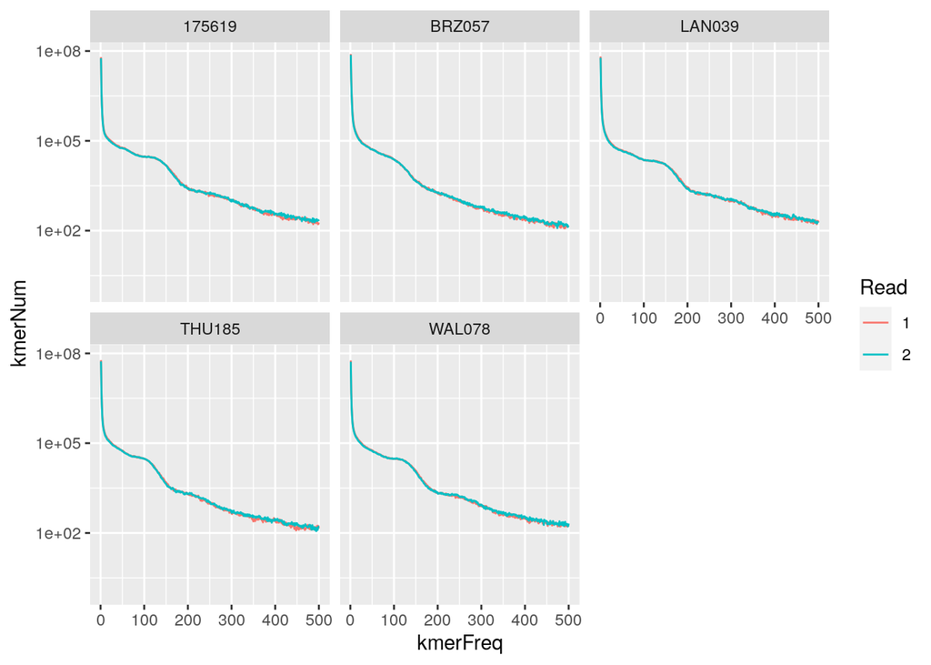

```r
library('ggplot2')
byRead <- read.table('byRead.hist', col.names = c('Sample','Read','kmerFreq','kmerNum'),
                     colClasses = c('factor','factor','numeric','numeric'))
ggplot(data = byRead, mapping = aes(x = kmerFreq, y = kmerNum, color = Read)) +
   geom_line() + xlim(1, 500) + scale_y_log10() + facet_wrap(~Sample)
```

Actaully, the mock samples do not have enough reads for a meaningful k-mer profile. In the rest, we can see the distribution of k-mer frequencies does resemble a mixture of an exponential (sequencing errors and possible contamination) and a normal that could be centered around 100. The problem is that the excess of low frequency k-mers makes it difficult to see the normal component. Changing the *k* up to 51 does not improve the profile.

Importantly, forward and reverse reads have very similar profiles.

## Comparison between lane 1 and lane 2

The challenge is to split fastq files by lane. I can use *gawk*. In ordre to avoid writing and reading from additional fastq files, I wanted to make `kat hist` read from standard input, but it does not work. I raised [an issue](https://github.com/TGAC/KAT/issues/163) in KAT’s github. For the moment, I will have to use files.

```bash
CHOSEN=(LAN039 BRZ057 THU185 WAL078 175619)
for sample in ${CHOSEN[@]}; do
   if [ ! -e $sample/lane1.hist ]; then
      if [ ! -e $sample/lane1.fasta ]; then
         gunzip -c ../../data/fastq/$sample*.fastq.gz | \
         gawk -v SAMPLE=$sample '(NR % 4 == 1){
            if (NR > 1) {
               split(NAME,A,/:/)
               printf ">%s\n%s\n", NAME, SEQ >> sprintf("%s/lane%i.fasta", SAMPLE, A[4])
            }
            NAME = $1
         }(NR % 4 == 2){
            SEQ  = $1
         }END{
            split(NAME, A, /:/)
            printf "%s\n%s\n", NAME, SEQ >> sprintf("%s/lane%i.fasta", SAMPLE, A[4])
         }' &
      fi
   fi
done
wait

for sample in ${CHOSEN[@]}; do
   if [ ! -e $sample/lane1.hist ]; then
      kat hist -N -t 4 -h 2000 -o $sample/lane1.hist $sample/lane1.fasta &> $sample/lane1.log &
      kat hist -N -t 4 -h 2000 -o $sample/lane2.hist $sample/lane2.fasta &> $sample/lane2.log &
   fi
done
wait
if [ ! -e byLane.hist ]; then
   gawk '(FNR == 1){
      split(FILENAME, A, /\//)
      SAMPLE = A[2]
      LANE = substr(A[3], 5, 1)
      ALLSAMPLES[SAMPLE] = 1
   }(/^[^#]/){
      F[SAMPLE, LANE, $1] = $2
   }END{
      for (s in ALLSAMPLES) {
         for (i = 1; i <= 2; i++) {
            for (j = 1; j <= 2000; j++) {
               print s "\t" i "\t" j "\t" F[s, i, j]
            }
         }
      }
   }' $(find . -name 'lane*.hist') > byLane.hist
fi
```

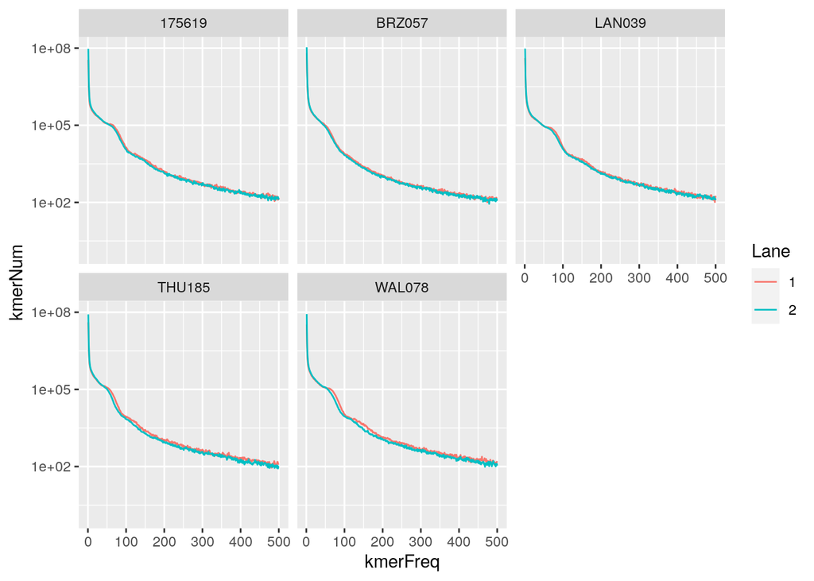

```r
byLane <- read.table('byLane.hist', col.names=c('Sample','Lane','kmerFreq','kmerNum'),
                     colClasses = c('factor','factor','numeric','numeric'))
ggplot(data = byLane, mapping = aes(x = kmerFreq, y = kmerNum, color = Lane)) +
   geom_line() + scale_y_log10() + xlim(1, 500) + facet_wrap(~Sample)
```

Lanes 1 and 2 have almost identical k-mer profiles in all 5 samples analysed here. Filtering low quality reads should improve the profile.

# References

Mapleson, Daniel, Gonzalo Garcia Accinelli, George Kettleborough, Jonathan Wright, and Bernardo J Clavijo. 2016. “KAT: a K-mer analysis toolkit to quality control NGS datasets and genome assemblies.” *Bioinformatics* 33 (4): 574–76. https://doi.org/10.1093/bioinformatics/btw663.